# Teoría de elementos finitos y su implementación (11/12/2018)

## Funciones que realizan tareas

### Programas usando archivos $M$-file

- Archivos de instrucciones
- Archivos de funciones

### Archivos de instrucciones

Un archivo o *script* de instrucciones consisten de una sucesión de instrucciones normales de MATLAB.

Las variables en un archivo de instrucciones son globales y, por tanto, cambiarán los valores del espacio de trabajo.

Los archivos de instrucciones son utilizados a menudo para introducir datos en una matriz grande.

### Archivos de funciones

Los archivos de funciones hacen que MATLAB tenga *capacidad de crecimiento*.

Se pueden crear funciones específicas para un problema concreto y a partir de su introducción, tendrán el mismo rango que las demás funciones del sistema.

Las variables en las funciones son locales.

También se puede declararse una variable como global.

```matlab
% Nombre del script figura1.m
% Ejecutar en el prompt de MATLAB como figura1.m
% figura 1
% shg
```

## Para direccionar una carpeta de trabajo

- Se puede utilizar las instrucciones: `cd`, `dir`.
- Se puede usar la instrucción `path`. Por ejemplo: `/home/user/Projects/MATLAB`.

## Creando un archivo de variables inicializados

```matlab
% datos.m
% Archivo de variables inicializadas
a = [2 3; 4 5];
b = [2 3]';
```

## Para cargar los datos

```matlab
% datos
a
b
```

```
a =

     2     3
     4     5


b =

     2
     3
```

## Instrucciones de control

### Instrucción `for ... end`

Sintáxis:

```
for NombVar = expresión
    instrucción_1
    instrucción_2
    ...
    instrucción_M
end
```

o

```
for NombVar = expresión, instrucción_1, instrucción_2, ..., instrucción_M end
```

donde:

`NombVar`: es el identificador de la variable.

`expresión`: usualmente tiene la siguiente forma: `Val_Inic:incr:Val_Fin` o `Val_Inic:Val_Fin`.

`Val_Inic`: valor inicial que a tomar la variable.

`incr`: incremento

`Val_Fin`: valor final que va a tomar la variable.

si expresión tiene la forma `Val_Inic:Val_Fin`, el incremento (implícito) es **uno**.

A continuación, se muestra un ejemplo ilustrativo:

[figure not shown]

Ejemplo: Escriba una función `comb(n,k)` en MATLAB para calcular $\dbinom{n}{k}=\dfrac{n!}{k!(n-k)!}$.

```
m
function z = comb(n, k)
    z = 1;
    for i=0:(k-1);
        z = z * (n-i)/(k-i);
    end
end
```

Guardar en el directorio de trabajo con el nombre `comb.m`. Para ejecutar esta función, ingrese `n=4` y `k=3`, ingrese:

```
m
comb(4,3)
```

```matlab
%%file comb.m
function z = comb(n, k)
    z = 1;
    for i = 0:(k-1)
        z = z * (n-i)/(k-i);
    end
end
```

```
Created file '/home/carlosal1015/GitHub/Finite-element-method-FEM/2018/Notebooks/comb.m'.
```

```matlab
n = 4; k = 3;
comb(n, k)
```

```
ans =

     4
```

Ejemplo: Escribir los cuadrados de los números naturales pares menores que $20$.

```
m
for i = 2:2:20
    disp(i^2)
end
```

```matlab
for i = 2:2:19
    disp(i^2)
end
```

```
     4

    16

    36

    64

   100

   144

   196

   256

   324
```

[figure not shown]

Aplicando el teorema del valor intermedio se obtiene el error: $$ \int_{a}^{b}\!\!f(x)\,\mathrm{d}x-T_n(f)=-\frac{h^2(b-a)}{12}f^{\prime\prime}\left(\xi\right),\quad h=\frac{b-a}{n}. $$

Ejemplo: Método trapezoidal compuesta

```
m
function inttrapS = int_trap(f, a, b, n)
% Regla trapezoidal compuesta
    h = (b-a)/n;
    t = (f(a) + f(b))/2:
    for i = 1:n-1
        t = t + f(a + i*h);
    end
    inttrapS = h * t
end
```

## Regla de Simpson

### Regla de Simpson $1/3$ o Regla de Simpson $(n=2)$:

$$ \begin{align*} K_2(f)&=\frac{b-a}{6}\left[f(a) + 4f\left(\frac{a+b}{2}\right) + f(b)\right].\\ E_2(f)&=-\frac{h^5}{90}f^{(4)}\left(\xi\right)=-\frac{1}{2880}{\left(b-a\right)}^{5}f^{(4)}\left(\xi\right),\quad a<\xi<b. \end{align*} $$ Si $h=\dfrac{b-a}{2}$, $x_0=a$, $x_1=x_0+h$, $x_2=x_1+h=b$, se tiene $$ K_2(f)=\frac{1}{3}h\left(f(x_0)+4f(x_1)+f(x_2)\right) $$

Ejemplo: Calcule la integral $I=\int_{I}x^2+y^2\mathrm{d}x\mathrm{d}y$ sobre el rectángulo $I=\left[-3,3\right]\times\left[-5,5\right]$ usando la función `trapz` proporcionada por MATLAB.

```matlab
% https://www.mathworks.com/help/matlab/ref/trapz.html
x = -3:.1:3;
y = -5:.1:5;
[X,Y] = meshgrid(x,y);
F = X.^2 + Y.^2;
I = trapz(y,trapz(x,F,2))
```

```
I =

  680.2000
```

[figure not shown]

## Regla compuesta de Simpson

De manera similar se obtiene la *Regla Compuesta de Simpson*. Sean $n=2m$ (par), $m\in\mathbb{N}$, $h=\dfrac{(b-a)}{n}$, $x_j=a+jh$, $j\in\left\{0,1,2,\ldots,n\right\}$ y $f\in\mathcal{C}^{4}\left[a,b\right]$.

Simplificando la regla de Simpson en los subintervalos $\left[x_{j-1},x_j\right]$ con $j\in\left\{1,2,\ldots, n\right\}$ se obtiene

$$ \int_{a}^{b}\!\!f(x)\,\mathrm{d}x=S_n\left[a,b\right]-\frac{h^4\left(b-a\right)}{180}\left(\frac{1}{m}\sum_{j=1}^{m}f^{(4)}\left(\xi_j\right)\right),\quad \xi_j\in\left]x_{j-1},x_j\right[. $$

Ejemplo: Método Compuesta de Simpson (1/3)

```
m
function intsimpS = int_simp(f, a, b, n)
% Se aplica M = 2*n veces el método de Simpson
% n+1 puntos de partición
    M = n/2; s = 0; h =(b-a)/n;
    s1 = f(a+h * (2*M-1)); s2 = 0;
    for j=1: M-1
        s1 = s1 + f(a + h*(2*j-1));
        s2 = s2 + f(a + h*(2*j));
    end
    intsimpS = h * (f(a) + 4*s1+2*s2+f(b))/3;
end
```

```matlab
x = 5; m = 24;
sum = 1; fact = 1;
for k=1:m
    fact = fact * x/k;
    sum = sum + fact;
end
disp(sum)
% Verificando: El resultado debe acercase a cero.
disp(sum - exp(5))
```

```
  148.4132

  -2.3740e-08
```

## Instrucción `if`

Sintáxis:

```
m
if relación
    instrucciones
end
```

Las instrucciones se ejecutarán solo si la relación es cierta.

La forma general de la sentencia `if` es

```
m
if expresión1
    sentencias1
elseif expresión2
    sentencias2
else
    sentencias3
end
```

Las sentencias serán ejecutadas si la parte real de la expresión tiene todos los elementos no ceros.

La partes `else` y `elseif` son opcionales.

La expresión usualmente tiene la forma `expr oper expr` donde `oper` es: `==`, `<`, `>`, `<=`, `>=`, `~=`.

Ejemplo:

```matlab
% Recuerde que n vale 4 :-)
if n < 0
    paridad = 0;
elseif rem(n,2) == 0
    paridad = 2;
else
    paridad = 1;
end
disp(paridad)
```

```
     2
```

## Relaciones:

Los operadores relacionales en MATLAB son

| Operador relacional | Significado |
| --- | --- |
| `<` | menor que |
| `>` | mayor que |
| `<=` | menor o igual que |
| `>=` | mayor o igual que |
| `==` | igual |
| `~=` | no igual |

Los operadores pueden conectarse o cuantificarse por los operadores lógicos

| Operador lógico | Significado |
| --- | --- |
| `&` | y (conjunción) |
| pipe o tubería | o (disyunción inclusiva) |
| `~` | no (negación) |

Cuando se aplican a escalares, la relación es realmente el escalar `1` o `0` dependiendo de si la relación es *verdadera* o *falsa*.

Ejemplo:

```matlab
4 < 6
3 > 8
4 == 4
3 == 6
```

```
ans =

  logical

   1


ans =

  logical

   0


ans =

  logical

   1


ans =

  logical

   0
```

Ejemplo: Escriba una función que encuentre el mayor de dos números `a`, `b`.

```
m
function SalMay = mayor(a, b)
if a > b
    SalMay = a;
else
    SalMay = b;
end
```

```matlab
%%file mayor.m
function SalMay = mayor(a, b)
if a > b
    SalMay = a;
else
    SalMay = b;
end
```

```
Created file '/home/carlosal1015/GitHub/Finite-element-method-FEM/2018/Notebooks/mayor.m'.
```

```matlab
mayor(4,5)
```

```
ans =

     5
```

```matlab
%%file grafica_hat.m
function grafica_hat(j, a, b, n, s)
% n segmentos
x = linspace(a, b, n + 1);
if j == 1
    xx = [x(1), x(2), x(n + 1)];
    yy = [1, 0, 0];
else
    if j == n
        xx = [x(1), x(n), x(n + 1)];
        yy = [0, 0, 1];
    else
        xx = [x(1), x(j - 1), x(j), x(j + 1), x(n + 1)];
        yy = [0, 0, 1, 0, 0];
    end
end
plot(xx, yy, s)
shg
end
```

```
Created file '/home/carlosal1015/GitHub/Finite-element-method-FEM/2018/Notebooks/grafica_hat.m'.
```

```matlab
%%file PL2.m
function [x, proy] = PL2(f, a, b, n)
    M = zeros(n + 1, n + 1);
    c = zeros(n + 1, 1);
    h = (b-a)/n;
    x = linspace(a, b, n + 1);

    for k = 1:n
        M_local = h * [1/3 1/6; 1/6 1/3];
        b_local = (h/2) * [ f(x(k)); f(x(k+1)) ];
        M(k:k + 1, k:k + 1) = M_local + M(k:k + 1, k:k + 1);
        c(k:k + 1, 1) = c(k:k + 1, 1) + b_local;
    end
proy = M\c;
%display(M)
%display(c)
end
```

```
Created file '/home/carlosal1015/GitHub/Finite-element-method-FEM/2018/Notebooks/PL2.m'.
```

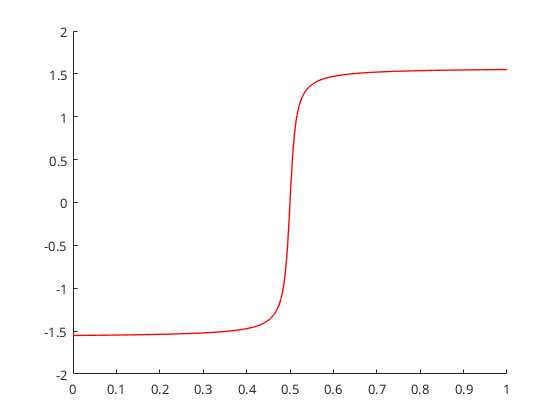

```matlab
% Corrida de la Proyección L2 de una función
% Grabe: run_PL2.m
a = 0;
b = 1;
n = 250; % n puede tomar valores de 100, 250, etc.
% f=@(x) 2*x.*sin(2*pi*x)+3;
% f=@(x) 0*x+1;
% f=@(x) x.^3.*(x-1).*(1-2*x);
epsilon = 0.01;
f = @(x) atan( (x-0.5)/epsilon );

[x, proy] = PL2(f, a, b, n);
hold on;
t = linspace(a, b, 250);
plot(t, f(t), '-r', 'LineWidth', 1);
shg;
hold off
```